[figure not shown]

[figure not shown]

### Colaboradores

[figure not shown]

[figure not shown]

# Talleres-R

Este repositorio contiene el desarrollo de los talleres de la clase [Taller de R](https://github.com/taller-R). Los talleres se irán subiendo a su respectiva carpeta debido las fechas pertinentes de entrega. Cada taller cuenta con tres carpetas **1. Resultados**, **2. Scripts** y **3. Datos** donde se encuentran gráficas, códigos y bases (procesadas y originales) para cada uno de los respectivos talleres.

El repositorio esta dividido de la siguiente manera:

- [*Taller 2:*](https://github.com/jorgeluis8ar/Talleres-R/tree/main/Taller%202) Introducción a la GEIH y cálculo del desempleo.
  - [*Resultados:*](https://github.com/jorgeluis8ar/Talleres-R/tree/main/Taller%202/Resultados) Resultados taller.
  - [*Scripts:*](https://github.com/jorgeluis8ar/Talleres-R/tree/main/Taller%202/Scripts) Códigos taller.
  - [*Datos*](https://github.com/jorgeluis8ar/Talleres-R/tree/main/Taller%202/Datos) Datos Taller.
    - [*GEIH 2019*](https://github.com/jorgeluis8ar/Talleres-R/blob/main/Taller%202/Datos/GEIH%202018.zip) Datos GEIH 2018.
    - [*GEIH 2020*](https://github.com/jorgeluis8ar/Talleres-R/blob/main/Taller%202/Datos/GEIH%202019.zip) Datos GEIH 2020.

## 1. Taller 2 - GEIH y algunas estadísticas

El DANE reporta para en la Gran Encuesta Integrada de Hogares (**GEIH**) variables relacionadas sobre las condiciones de empleo de las personas. De esta manera se puede desagregar resultados por departamento, mes y año para las variables de interés. Para este taller se utilizan principalmente las variables para características como el **analfabetismo**, **educación superior** e **ingresos laborales** de las personas. COn esto en mente, el siguiente análisis desagrega estas variables por año, mes, sexo y nivel (urbano o rural).

| Departamento | Tasa de analfabetismo 2018 | Tasa de analfabetismo 2019 | Crecimiento analfabetismo (%) | Tasa graduados educación superior 2018 | Tasa graduados educación superior 2019 | Crecimiento graduados eduación superior (%) |
| --- | --- | --- | --- | --- | --- | --- |
| Antioquia | 9,094 | 9,217 | 1,352 | 7,232 | 7,639 | 5,627 |
| Atlantico | 8,679 | 8,888 | 2,408 | 7,88 | 8,01 | 1,649 |
| Bogota D.C | 5,537 | 6,119 | 10,511 | 13,344 | 13,438 | 0,704 |
| Bolivar | 12,805 | 11,378 | -11,144 | 5,218 | 5,466 | 4,752 |
| Boyaca | 9,081 | 8,638 | -4,878 | 7,01 | 7,297 | 4,094 |
| Caldas | 9,214 | 8,958 | -2,778 | 6,394 | 6,373 | -0,328 |
| Caqueta | 13,19 | 12,412 | -5,898 | 3,92 | 4,136 | 5,51 |
| Cauca | 10,147 | 10,664 | 5,095 | 4,514 | 4,355 | -3,522 |
| Cesar | 13,867 | 12,75 | -8,055 | 4,726 | 5,229 | 10,643 |
| Cordoba | 14,371 | 14,614 | 1,69 | 4,9 | 5,376 | 9,714 |
| Cundinamarca | 7,991 | 7,698 | -3,666 | 4,726 | 5,33 | 12,78 |
| Choco | 22,154 | 21,009 | -5,168 | 4,525 | 4,772 | 5,458 |
| Huila | 11,634 | 10,764 | -7,478 | 5,453 | 5,334 | -2,182 |
| La Guajira | 18,348 | 18,657 | 1,684 | 4,75 | 5,437 | 14,463 |
| Magdalena | 14,269 | 14,139 | -0,911 | 5,015 | 4,599 | -8,295 |
| Meta | 9,205 | 9,423 | 2,368 | 5,672 | 6,035 | 6,399 |
| Nariño | 11,365 | 11,88 | 4,531 | 5,483 | 6,329 | 15,429 |
| N. Santander | 11,62 | 11,902 | 2,426 | 4,616 | 4,831 | 4,657 |
| Quindio | 9,75 | 9,363 | -3,969 | 5,777 | 6,193 | 7,2 |
| Risaralda | 8,688 | 9,356 | 7,688 | 5,601 | 5,627 | 0,464 |
| Santander | 8,222 | 8,239 | 0,206 | 7,54 | 7,343 | -2,612 |
| Sucre | 15,992 | 14,782 | -7,566 | 4,771 | 5,235 | 9,725 |
| Tolima | 10,674 | 10,248 | -3,991 | 4,958 | 5,506 | 11,052 |
| V. Cauca | 8,263 | 8,545 | 3,412 | 6,592 | 6,636 | 0,667 |
| Promedio Nacional | 11,423 | 11,235 | -0,922 | 5,859 | 6,105 | 4,752 |

Los resultados de la tasa de analfabetismo se presentan en la primera [gráfica](https://github.com/jorgeluis8ar/Talleres-R/blob/main/Taller%202/Resultados/analfabetismo.jpeg) para el promedio departamental de 2019. Los resultado de la tasa de graduados de educación superior se presentan en la segunda [gráfica](https://github.com/jorgeluis8ar/Talleres-R/blob/main/Taller%202/Resultados/educacion.jpeg) para el promedio departamental de 2019.

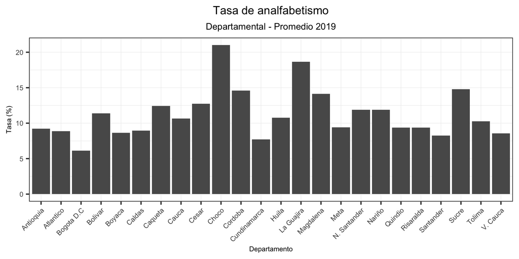

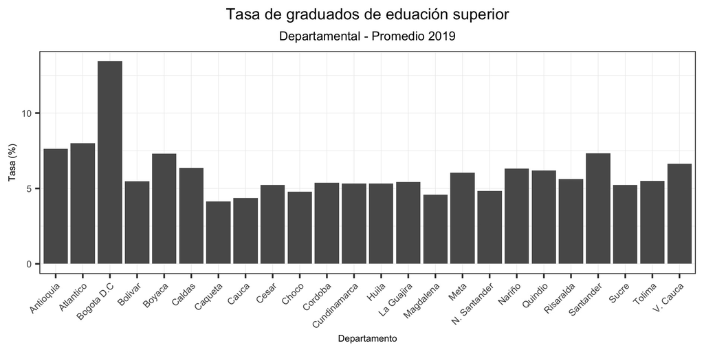

Por último se obtienen los ingresos laborales para las personas entre 18 y 28 años por departamento, mes, sexo y sexo. Los resultados se presentan en la siguiente tabla:

| Mes | Nivel | Hombres 2019 | Mujeres 2019 | Brecha 2019 | Hombres 2018 | Mujeres 2018 | Brecha 2018 |
| --- | --- | --- | --- | --- | --- | --- | --- |
| Enero | Rural | 569.304 | 455.403 | 113.901 | 551.790 | 430.301 | 121.489 |
| Enero | Urbano | 898.964 | 862.852 | 36.112 | 835.788 | 814.215 | 21.573 |
| Febrero | Rural | 626.656 | 410.149 | 216.507 | 632.833 | 459.234 | 173.599 |
| Febrero | Urbano | 873.998 | 828.550 | 45.448 | 865.628 | 805.478 | 60.150 |
| Marzo | Rural | 567.910 | 466.403 | 101.507 | 568.673 | 436.645 | 132.028 |
| Marzo | Urbano | 880.919 | 862.761 | 18.158 | 870.781 | 818.247 | 52.534 |
| Abril | Rural | 709.331 | 391.934 | 317.397 | 610.413 | 462.077 | 148.336 |
| Abril | Urbano | 903.627 | 840.882 | 62.745 | 880.654 | 806.462 | 74.192 |
| Mayo | Rural | 630.139 | 503.401 | 126.738 | 609.699 | 500.381 | 109.318 |
| Mayo | Urbano | 866.233 | 858.215 | 80.018 | 906.951 | 812.518 | 94.433 |
| Junio | Rural | 541.968 | 406.954 | 135.014 | 583.010 | 383.173 | 199.837 |
| Junio | Urbano | 951.109 | 854.104 | 97.005 | 892.279 | 817.996 | 74.283 |
| Julio | Rural | 621.655 | 448.162 | 173.493 | 616.984 | 418.515 | 198.469 |
| Julio | Urbano | 913.083 | 845.893 | 67.190 | 882.306 | 801.780 | 80.526 |
| Agosto | Rural | 616.059 | 459.452 | 156.607 | 631.198 | 423.065 | 208.133 |
| Agosto | Urbano | 929.294 | 853.104 | 76.190 | 882.397 | 829.671 | 52.726 |
| Septiembre | Rural | 608.681 | 463.259 | 145.422 | 578.029 | 327.678 | 250.351 |
| Septiembre | Urbano | 921.875 | 853.893 | 67.982 | 860.870 | 784.478 | 76.392 |
| Octubre | Rural | 609.525 | 390.738 | 218.787 | 592.083 | 392.151 | 199.932 |
| Octubre | Urbano | 894.506 | 868.393 | 26.113 | 869.781 | 806.524 | 63.257 |
| Noviembre | Rural | 539.278 | 425.787 | 113.491 | 553.814 | 415.529 | 138.285 |
| Noviembre | Urbano | 916.759 | 870.711 | 46.048 | 897.987 | 806.257 | 91.730 |
| Diciembre | Rural | 602.854 | 496.628 | 106.226 | 606.253 | 450.394 | 155.859 |
| Diciembre | Urbano | 894.480 | 859.787 | 34.693 | 875.292 | 798.823 | 76.469 |
| Promedio |  | 753.667 | 649.333 | 104.333 | 735.667 | 616.733 | 118.667 |

El ingreso laboral promedio para los hombres en el 2019 fue de **753.675** pesos, mientras que para 2018 fue de **735.646** pesos. Esto implica un crecimiento de los ingresos laborales nominales de **2,45%**. Para las mujeres el ingreso laboral promedio para 2019 fue de **649.059** pesos, mientras que para 2018 se encontró en **616.733** pesos. Con un aumento nominal del salario promedio de **5,24%**. Estos datos muestran una brecha salarial entre los hombres y las mujeres. Aunque este resultado disminuyó en 14.296 pesos para 2019 (pasando de 118.913 pesos en 2018 a 104.616 pesos en 2019).

| Nivel | Hombres 2019 | Mujeres 2019 | Brecha 2019 | Hombres 2018 | Mujeres 2018 | Brecha 2018 |
| --- | --- | --- | --- | --- | --- | --- |
| Rural | 603.613 | 443.189 | 160.424 | 594.564 | 424.928 | 169.636 |
| Urbano | 903.737 | 854.928 | 48.808 | 876.726 | 808.537 | 68.188 |

| Nivel | Rural | Urbano | Brecha |
| --- | --- | --- | --- |
| 2019 | 523.401 | 879.333 | 355.931 |
| 2018 | 509.746 | 842.631 | 332.885 |

Los resultados de la tasa de analfabetismo se presentan en el primer [mapa](https://github.com/jorgeluis8ar/Talleres-R/blob/main/Taller%202/Resultados/mapa_analfabetismo.jpeg) para el promedio departamental de 2019. Los resultado de la tasa de graduados de educación superior se presentan en la segunda [mapa](https://github.com/jorgeluis8ar/Talleres-R/blob/main/Taller%202/Resultados/mapa_graduados.jpeg) para el promedio departamental de 2019.

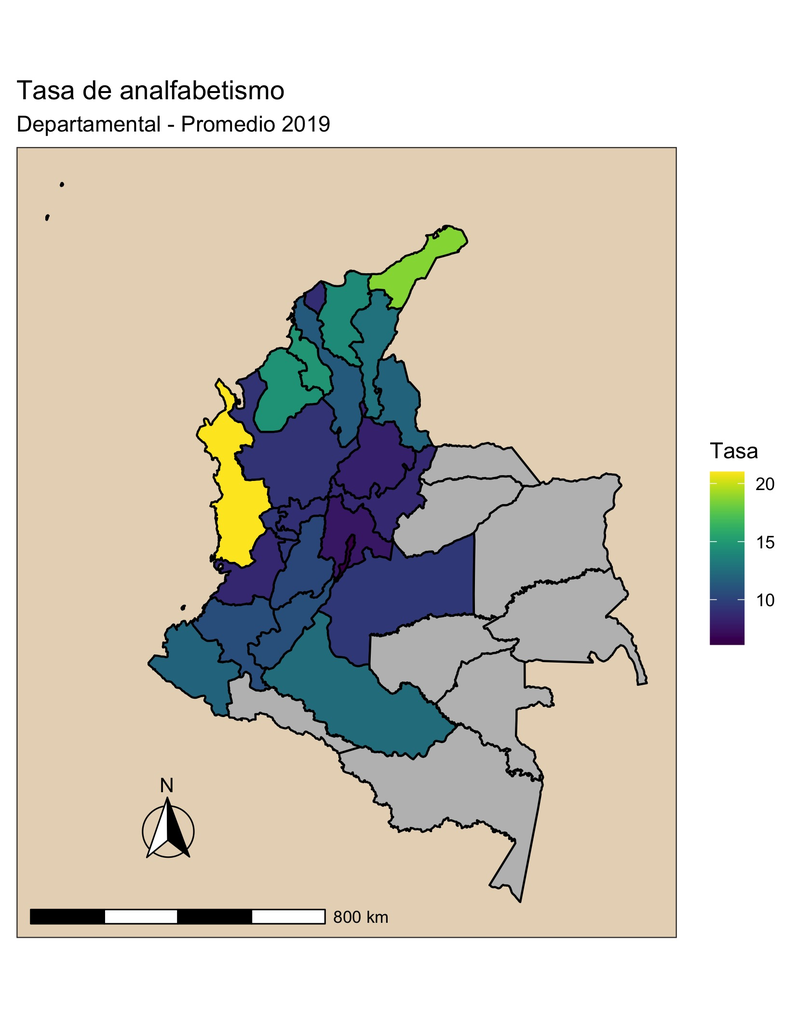

[figure not shown]

Por último se aprovecha la construcción de la GEIH para presentar la tasa de desempleo mensual desde enero de 2018 hasta diciembre de 2019. Estos resultados se presentan en la [gráfica](https://github.com/jorgeluis8ar/Talleres-R/blob/main/Taller%202/Resultados/desempleo.jpeg). Se observa el periodo con mayore nivele de desempleo en enero de 2019 con un valor de **12,8%** y el menor valor para noviembre de 2018 con un valor de **8,8%**.

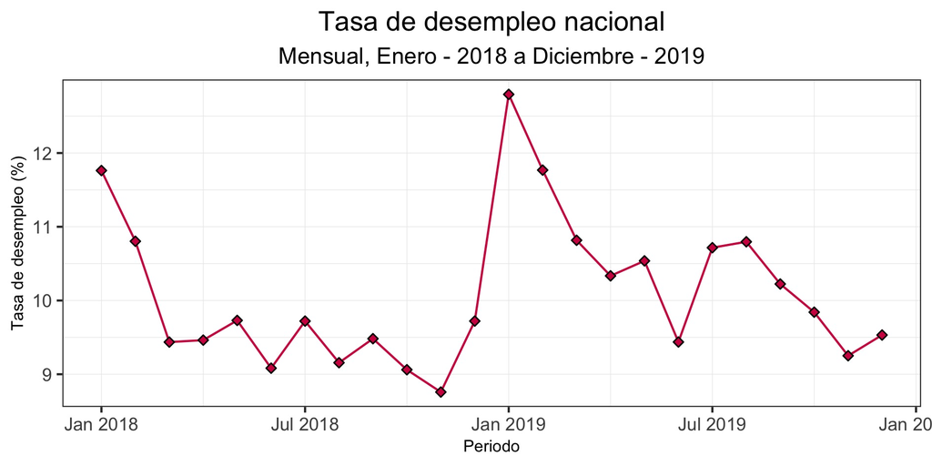